# Gaming and COVID-19

Bahara Haidari

May 2021

Here is a [link](https://github.com/Bahara25/psy6422_final_project_bahara) to my Github Repository

## Project Introduction

COVID-19 has affected the world in a multitude of ways including economic downfall, social disruption, and death. The pandemic has also impacted upon people’s mental health and in response to this many people have taken up old and new hobbies and interests as a way to cope. This project will investigate how gaming frequency has changed as a result of the COVID-19 pandemic and whether loneliness has an impact.

```r
#setting the path for the data

file_path <- "~/gaming_project/data"

setwd(file_path)

#library here to tell R where my data is

library(here)
#load data into R

#separate the data with ; as the data is unclean and within one column

gamingdata <- read.csv(here("gaming_and_covid_raw.csv"), header = TRUE, sep = ";")
```

## Data Origins

OSF.io was searched to find a dataset about gaming. A [dataset](https://osf.io/jdxyr/) was found of which the data was collected in April and May of 2020 and consisted of 741 German-speaking participants, with a mean age of 31.75 years. During this time period, Germany was under lockdown due to the pandemic. Participants were recruited via social networks and gaming forums.

Demographic data was collected including age, gender, employment status as well as data about the situation during COVID-19. For example, whether they had family/friends in the high-risk COVID-19 group, their lifestyle changes, time for leisure activities etc. In addition, gaming and loneliness variables were measured including gaming frequency, motives for gaming, and loneliness was measured using the UCLA Loneliness Scale.

```r
head(gamingdata)
```

```
##   ï..age gender employ emplyoment_change current_country live_in_home_country
## 1     31      2      3                NA         Germany                    2
## 2     29      1      4                NA         Germany                    2
## 3     25      2      2                NA         Germany                    2
## 4     51      2      3                NA         Germany                    2
## 5     28      2      3                NA         Germany                    2
## 6     40      1      3                NA         Austria                    2
##   family_status fami_cor living_situation livwadu livwchi time_leisure gam_freq
## 1             2        2                2       1       0            3        2
## 2             2        1                2       1       0            4        2
## 3             1        2                3       2       0            4        2
## 4             2        1                3       1       0            3        2
## 5             2        2                2       0       0            4        2
## 6             2        2                2       0       0            4        2
##   beh_ch_general beh_ch_single_player beh_ch_coll beh_ch_comp beh_ch_conn
```

[output cut: 97 more lines]

## Research Questions

Two research questions will be investigated.

The first research question will look into how many people played much less, less, the same, more or much more general video games during the pandemic compared to before.

The second research question will look at how loneliness scores differ between those who play general video games much less, less, similar to, more or much more during than before the pandemic.

## Data Preparation

```r
#load tidyverse and dplyr

library(tidyverse)
library(dplyr)

gamingdatac <- gamingdata

#remove umlaut and dots from the age column

gamingdatac <- gamingdatac %>% rename(age = ï..age)


#select the variables wanted for the visualisations

gamingdatac <- gamingdatac %>%
  select(beh_ch_general, Loneliness_sum)

head(gamingdatac)
```

```
##   beh_ch_general Loneliness_sum
## 1              3             32
## 2              4             33
## 3              3             47
## 4              2             32
## 5              3             31
## 6              4             32
```

## Visualisations

**First Visualisation**

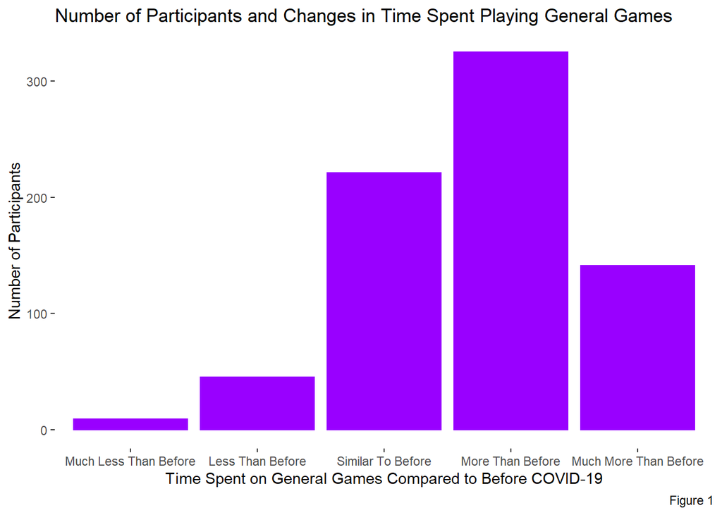

```r
#library ggplot to create visualisations

library(ggplot2)

ggplot(data = gamingdatac, aes(x = beh_ch_general, fill = beh_ch_general)) +
  geom_bar(fill = "#9900FF", colour = "#9900FF") +

#remove the grid lines, background colour and borderlines

  theme(panel.background = element_blank()) +

#use scale_x_discrete to change labels of the values on the x axis

  scale_x_discrete(limit = c("Much Less Than Before", "Less Than Before", "Similar To Before","More Than Before","Much More Than Before")) +


#label axes, title and caption

  labs(x = "Time Spent on General Games Compared to Before COVID-19",
       y = "Number of Participants",
       title = "Number of Participants and Changes in Time Spent Playing General Games",
       caption = "Figure 1")
```

```r
#save the visualisation as a png

ggsave("general_game_numbers.png")
```

**Second Visualisation**

[figure not shown]

```r
#library gganimate

library(gganimate)

#stat_identity included rather than geom_bar(stat="identity") so that the y axis data isn't aggregated

ggplot() +
    stat_identity(data = gamingdatac,
                  aes(x = beh_ch_general,
                      y = Loneliness_sum,
                      fill = factor(beh_ch_general)),
                      geom = "col") +

#use transition states to have the bars transition in

    transition_states(beh_ch_general, wrap=FALSE) +
    shadow_mark() +

#use coord_cartesian to zoom into the y axis scale

    coord_cartesian(ylim = c(50,80)) +

#scale_fill_manual allows the bars in the visualisation to be coloured manually

    scale_fill_manual(values = c("#CC00CC", "#CC00FF", "#9900FF", "#6600FF", "#3300FF")) +

#remove the grid lines, background colour and borderlines

    theme(panel.background = element_blank()) +

#use scale_x_discrete to change labels of the values on the x axis

    scale_x_discrete(limit = c("Much Less Than Before", "Less Than Before", "Similar To Before","More Than Before","Much More Than Before")) +

#label the axes, title and caption

    labs(x = "Time Spent on General Games Compared to Before COVID-19",
         y = "UCLA Loneliness Sum",
         title = "Impact of Loneliness and COVID-19 on Time Spent Playing General Games",
         caption = "Figure 2") +

#remove legend as provides unnecessary information

    theme(legend.position = "none")
```

```r
#save visualisation as a gif

anim_save("general_games_loneliness_gif.gif")
```

```r
#extract script

library(knitr)

options(knitr.duplicate.label = "allow")

purl("baharahaidari_psy6422_final_project.Rmd", output="gaming_project_psy6422_script.R")
```

```
##
##
## processing file: baharahaidari_psy6422_final_project.Rmd
```

[output not shown]

```
## output file: gaming_project_psy6422_script.R
```

```
## [1] "gaming_project_psy6422_script.R"
```

## Summary

The first visualisation reveals that most participants play general video games more during than before COVID-19, whilst the least number of participants stated that they spent much less time playing general video games during than before the pandemic. Therefore, COVID-19 or factors associated with the pandemic may play a role in increasing the frequency that people play video games.

If I had more time I would look into other factors that may influence how much time people spend gaming and investigate the effects on different types of games such as single player or collaborative games.